# Image Process: Super-Revolution of Low Revolution Images

Guanren Wang

2019-3-27

## Project summary:

This file organizes **all computational steps** for evaluating baseline image processing framework.  
All major steps of my computation are computed by **self-defined functions**. If you want to see code of these functions, please click [here](https://github.com/Grandeurwang/Super_Revolution_of_low_revoltion_images/tree/master/lib)  
For computational steps of improved model, please click [here](https://github.com/Grandeurwang/Super_Revolution_of_low_revoltion_images/tree/master/doc)  
All the code is available on [GitHub](https://github.com/Grandeurwang/Super_Revolution_of_low_revoltion_images)

The baseline model(GBM) is computed via Google Cloud VM with machine type: **n1-standard-16 (16 vCPUs, 60 GB memory)** and CPU platform: **Intel Broadwell**. In view of heavy computing workload, I recommend you use VM to reproduce.

### Load libraries

```r
if(!require("EBImage")){
  source("https://bioconductor.org/biocLite.R")
  biocLite("EBImage")
  library("EBImage")
}

if(!require("gbm")){
  install.packages("gbm")
  library("gbm")
}

library("EBImage")
library("gbm")
```

### Parallel Computing Setup

```r
if(!require("doParallel")){
  install.packages("doParallel")
  library("doParallel")
}

# Real physical cores in the computer
cores <- detectCores()

if(cores>1){

  if(.Platform$OS.type=="windows"){
    cl <- makeCluster(cores)
    registerDoParallel(cl, cores=cores)
  }
  else{
    if(!require("doMC")){
      install.packages("doMC")
      library("doMC")
    }
    registerDoMC(cores)
  }

  run.parallel=TRUE

}else
  run.parallel=FALSE
cores<-cores
```

## Step 0: Specify Directories.

Provide directories for training images. **Low-resolution (LR)** image set and **High-resolution (HR)** image set will be in different subfolders.

```r
set.seed(123)
# use relative path for reproducibility

train_dir <- "../data/train_set/" # This will be modified for different data sets.
train_LR_dir <- paste(train_dir, "LR/", sep="")
train_HR_dir <- paste(train_dir, "HR/", sep="")
train_label_path <- paste(train_dir, "label.csv", sep="")
```

## Step 1: Set Up Controls For Evaluation Experiments.

In this chunk, we have a set of controls for the evaluation experiments.

- (T/F) cross-validation on the training set
- (number) K, the number of CV folds
- (T/F) whether run training
- (T/F) process features for training set
- (T/F) run evaluation on an independent test set
- (T/F) process features for test set

```r
run.cv=T # run cross-validation on the training set
K <- 5  # number of CV folds
run.train=TRUE # whether run training
run.feature.train=TRUE # process features for training set
run.test=TRUE # run evaluation on an independent test set
run.feature.test=TRUE # process features for test set
```

Using cross-validation or independent test set evaluation, we compare the performance of models with different specifications. In this project, we use GBM with different `depth`. In the following chunk, we list, in a vector, setups (in this case, `depth`) corresponding to models that we will compare. In your project, you might compare very different classifiers. You can assign them numerical IDs and labels specific to your project.

```r
model_values <- 2:6
model_labels = paste("GBM with depth =", model_values)
```

## Step 2: Import Training Images Class Labels.

We provide extra information of image label: car (0), flower (1), market (2). These labels are not necessary for your model.

```r
extra_label <- read.csv(train_label_path, colClasses=c("NULL", NA, NA))
```

## Step 3: Construct Features and Responses

`feature.R` should be the wrapper for all your feature engineering functions and options. The function `feature( )` should have options that correspond to different scenarios for your project and produces an R object that contains features and responses that are required by all the models you are going to evaluate later.

`feature.R`:

- Input: a path for low-resolution images.
- Input: a path for high-resolution images.
- Output: an RData file that contains extracted features and corresponding responses

| Running Time | HPC | Pixelbook | old laptop |
| --- | --- | --- | --- |
| Parallel | 19 | 55 | 80 |
| Non-Parallel | 51 | 33 | 90 |

```r
if(run.parallel)
  source("../lib/feature_parallel.R") else
    source("../lib/feature.R")
```

```r
tm_feature_train <- NA
if(run.feature.train){
  tm0=proc.time()
  dat_train <- feature(train_LR_dir, train_HR_dir)
  tm_feature_train=proc.time()-tm0

  save(dat_train, file="../output/feature_train.RData")
}else{
  load("../output/feature_train.RData")
}
feat_train <- dat_train$feature
label_train <- dat_train$label
rm(dat_train)
tmp=gc() # release memory
```

## Step 4: Train a classification model with training images

Call the train model and test model from library.

`train.R` and `test.R` should be wrappers for all your model training steps and your classification/prediction steps.

`train.R`:

- Input: a path that points to the training set features and responses.
- Output: an RData file that contains trained classifiers in the forms of R objects: models/settings/links to external trained configurations.

`test.R`:

- Input: a path that points to the test set features.
- Input: an R object that contains a trained classifier.
- Output: an R object of response predictions on the test set. If there are multiple classifiers under evaluation, there should be multiple sets of label predictions.

```r
if(run.parallel)
  source("../lib/train_parallel.R") else
    source("../lib/train.R")

### The test parallel will increase much more time, so we use non-paralleled one
source("../lib/test.R")
```

### Model selection with cross-validation

- Do model selection by choosing among different values of training model parameters, that is, the interaction depth for GBM in this example.

```r
source("../lib/cross_validation.R")
if(run.cv){
  err_cv <- array(dim=c(length(model_values), 2))
  for(k in 1:length(model_values)){
    cat("k=", k, "\n")
    err_cv[k,] <- cv.function(feat_train, label_train, model_values[k], K)
    system("free -m")
  }
  save(err_cv, file="../output/err_cv.RData")
}else{
  load("../output/err_cv.RData")
}
tmp=gc() # release memory
```

### Visualize cross-validation results

```r
plot(model_values, err_cv[,1], xlab="Interaction Depth", ylab="CV Error",
       main="Cross Validation Error", type="n", ylim=c(0, 0.01))
points(model_values, err_cv[,1], col="blue", pch=16)
```

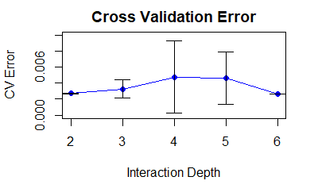

```r
lines(model_values, err_cv[,1], col="blue")
arrows(model_values, err_cv[,1]-err_cv[,2], model_values, err_cv[,1]+err_cv[,2],
        length=0.1, angle=90, code=3)
```

```r
psnr<-10*log10(1/err_cv[,1])
plot(model_values, psnr, xlab="Interaction Depth", ylab="PSNR",
       main="PSNR", type="n")
points(model_values, psnr, col="red", pch=16)
```

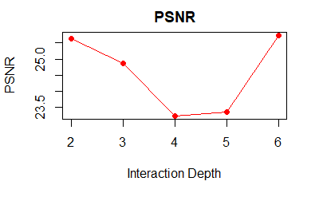

```r
lines(model_values, psnr, col="red")
```

### Choose the “best” parameter value

```r
model_best=model_values[1]

model_best <- model_values[which.min(err_cv[,1])]
cat("The min cv is",min(err_cv[,1]),"for depth",model_best,"\n")

par_best <- list(depth=model_best)
```

[output not shown]

### Train the model with the entire training set using the selected model (model parameter) via cross-validation.

```r
source("../lib/train_parallel.R")
if(run.train){
  tm0=proc.time()
  fit_train <- train(feat_train, label_train, par_best)
  tm_train=proc.time()-tm0
  save(fit_train, file="../output/fit_train.RData")
}else{
  load("../output/fit_train.RData")
}
tmp=gc()
```

## Step 5: Super-resolution for test images

Feed the final training model with the completely holdout testing data.

`superResolution.R`:

- Input: a path that points to the folder of low-resolution test images.
- Input: a path that points to the folder (empty) of high-resolution test images.
- Input: an R object model with tuned parameters.
- Output: construct high-resolution versions for each low-resolution test image.

```r
# useually we use parallel computing to generate new images, but because of incompatibility of operating systems, superrevolution doesn't work, in this case we could do this without parallel computing.
# for non-parallel computing, just delete pound sign below

# run.parallel=F
if(run.parallel)
  source("../lib/superResolution_parallel.R") else
    source("../lib/superResolution.R")
test_dir <- "../data/test_set/" # This will be modified for different data sets.
test_LR_dir <- paste(test_dir, "LR/", sep="")
test_HR_dir <- paste(test_dir, "HR/", sep="")

if(run.test){
  tm0=proc.time()
  superResolution(test_LR_dir, test_HR_dir, fit_train)
  tm_test=proc.time()-tm0
}
run.parallel=T
```

## Step 6: Summarize Running Time

Prediction performance matters, so does the running times for constructing features and for training the model, especially when the computation resource is limited.

```r
cat("Time for constructing training features=", tm_feature_train[3], "s \n")
cat("Time for training model=", tm_train[3], "s \n")
cat("Time for super-resolution=", tm_test[3], "s \n")
```

[output not shown]

## Step 7: Calculate MSE and PSNR

```r
train_dir <- "../data/train_set/HR/"
test_dir <- "../data/test_set/HR/"
source("../lib/Evaluation.R")
mp=msepsnr(train_dir, test_dir)
cat("MSE is", mp[1],'\n')

cat("PSNR is", mp[2])
```

[output not shown]

## Step 8: Stop Parallel Computing

```r
if(run.parallel & .Platform$OS.type=="windows"){
  stopImplicitCluster()
  stopCluster(cl)
}
```

## Conclusion:

### Steps:

Our baseline model consists of four **steps**:  
1. Preprocessing and Feature Extraction  
2. Model training, evaluation(parameter tuning) and selection  
3. Making prediction using selected model  
4. Evaluating prediction and running time of model

### Results comparison:

We ran feature extraction by sampling 1000 points from the LR image pixels and takin the 8 neighboring pixels for each point as features.

Optimal depth is 6 with cross-validation error 0.00266912

Time for constructing training features= 92.81 s Time for training model is around 3 hours Time for super-resolution= 2717.55 s (1500 images)

**MSE** is 0.002669120  
**PSNR** is 25.73632

It is better than the **nerest-neighbor method** which uses the value of nearby translated pixel values for the output pixel values. MSE of this method is 0.004035 and PSNR is 25.3926.

Additionally, it is better than **bicubic interpolation** as well, which uses the weighted average of four translated pixel values for each output pixel value. MSE is 0.004927 and the PSNR is 24.1553.